# Week 4 Project

Nathan Young

2023-11-15

## Background

Using devices such as *Jawbone Up*, *Nike FuelBand*, and *Fitbit* it is now possible to collect a large amount of data about personal activity relatively inexpensively. These type of devices are part of the quantified self movement – a group of enthusiasts who take measurements about themselves regularly to improve their health, to find patterns in their behavior, or because they are tech geeks. One thing that people regularly do is quantify how much of a particular activity they do, but they rarely quantify how well they do it. In this project, your goal will be to use data from accelerometers on the belt, forearm, arm, and dumbell of 6 participants. They were asked to perform barbell lifts correctly and incorrectly in 5 (classe variable) different ways. More information is available from the [website](http://web.archive.org/web/20161224072740/http:/groupware.les.inf.puc-rio.br/har)

(see the section on the Weight Lifting Exercise Dataset).

## Data

Data for this project was retrieved from the proved url’s for training and test data. To prevent accessing the data repeatedly, it’s good practice to surround a download call with a test if the file already exists. When loading the data, a warning was raised that there were parsing issues; when `problems(data)` was called, I found that there were several `#DIV/0!` strings that were preventing a clean import. This was managed by including the string in the na character list.

```r
url_train <- "https://d396qusza40orc.cloudfront.net/predmachlearn/pml-training.csv"
url_test <- "https://d396qusza40orc.cloudfront.net/predmachlearn/pml-testing.csv"

if (!file.exists("./data/train.csv")) {
  download.file(url_train, destfile = "./data/train.csv")
}

if (!file.exists("./data/test.csv")) {
  download.file(url_test, destfile = "./data/test.csv")
}

train <- read_csv("./data/train.csv", na = c("NA", "", "#DIV/0!"), show_col_types = FALSE)
test <- read_csv("./data/test.csv", na = c("NA", "", "#DIV/0!"), show_col_types = FALSE)
```

## Exploration

The first step in this process was to identify which variables in the dataset are useful for the analysis. When looking at a summary of the dataset, many of the columns were mostly `NA` so these columns were removed.

Additionally, the predictor “classe”, and columns 1 - 7 can be removed as these contain information not relevant to predicting “classe”. Note that for the analyses without PCA, the `classe` variable is left in the train set.

To visually see whether variables tended to be correlated, please see the Appendix for a correlation plot of all 52 variables included in the analysis.

Percentage of exercises in each category

| A | B | C | D | E |
| --- | --- | --- | --- | --- |
| 28.44% | 19.35% | 17.44% | 16.39% | 18.38% |

## Analysis

This is a classification problem where the goal is to classify the data into one of 5 groups: A, B, C, D, or E. As such, classification trees and decision trees from `randomForest` are classic choices. There are also 38 variables that are highly correlated with each other so doing a preprocess with PCA would reduce dimension of dataset, but will likely reduce model accuracy. To evaluate which approach is best, I decided to build three models:

1. A classification tree with `caret::train` and `rpart` using a PCA preprocess step.
2. A classification tree identical to 1. but without PCA
3. A random forest model with `randomForest::randomForest`

Cross validation is included in the first two models by passing an argument to `trControl = trainControl(method = "cv", number = 3)`.

To measure out of sample error rates, the provided training data was split into a further training and validation set. The out of sample error rate is calculated as the `1 - Accuracy` of each model on the validation set. This out of sample error rate, in addition to in sample accuracy, is used to evaluate which model is best to apply to the test set.

### Creation of Validation Set

A validation set is created by splitting the provided training set with `createDataPartition` where 70% of the data is used for the new training set and 30% for validation.

```r
# Split training into train and validation sets.
inTrain <- createDataPartition(y=train_subset$classe, p=0.7, list=F)
train_subset_2 <- train_subset[inTrain,]
valid <- train_subset[-inTrain,]
```

### Classification Tree with PCA

The first model evaluated is a classification tree which is available in the `caret` package via `method = "rpart"`. I chose to perform a principal components analysis on this model as there were several variables that were highly correlated.

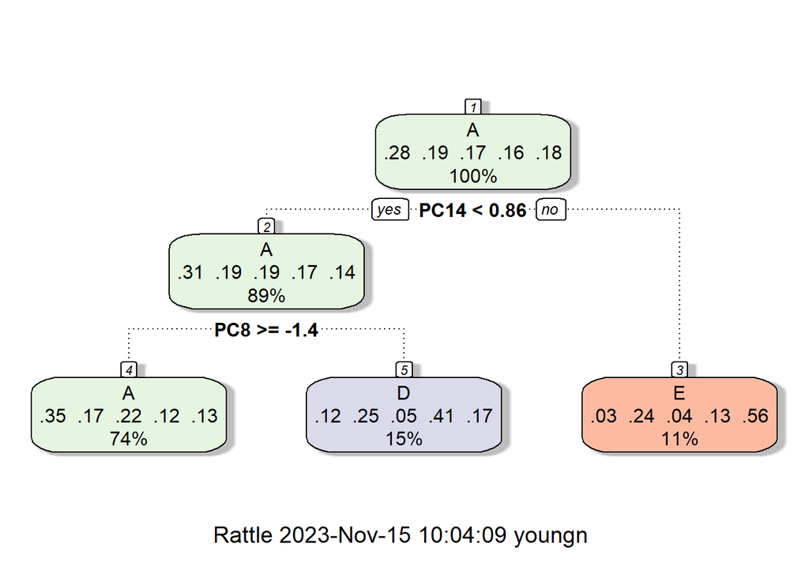

```r
# PCA without "classe"
preProc <- preProcess(train_subset_2[,-53],method="pca")
trainPC <- cbind(classe = train_subset_2$classe,
                 predict(preProc,train_subset_2[,-53]))
validPC <- cbind(classe = valid$classe,
                 predict(preProc, valid[,-53]))

mdl_rpart_PC <- train(classe ~ .,
                      method="rpart",
                      trControl = trainControl(method = "cv", number = 3),
                      data=trainPC)
pred_rpart_PC <- predict(mdl_rpart_PC, trainPC)
cM_rpart_PC <- confusionMatrix(as.factor(train_subset_2$classe), pred_rpart_PC)
cM_rpart_PC_valid <- confusionMatrix(as.factor(valid$classe),
                                     predict(mdl_rpart_PC, validPC))


fancyRpartPlot(mdl_rpart_PC$finalModel)
```

The resulting classification tree above seems to do a poor job of classifying the `classe` outcome as it only predicts categories “A”, “D” and “E” based on only PC14 and PC8. As categories “B” and “C” comprise 37% of the data, this model is guaranteed to have a poor accuracy.

### Classification Tree without PCA

The second model evaluated is a classification tree which is available in the `caret` package via `method = "rpart"`. On this model, I didn’t preprocess with principal components.

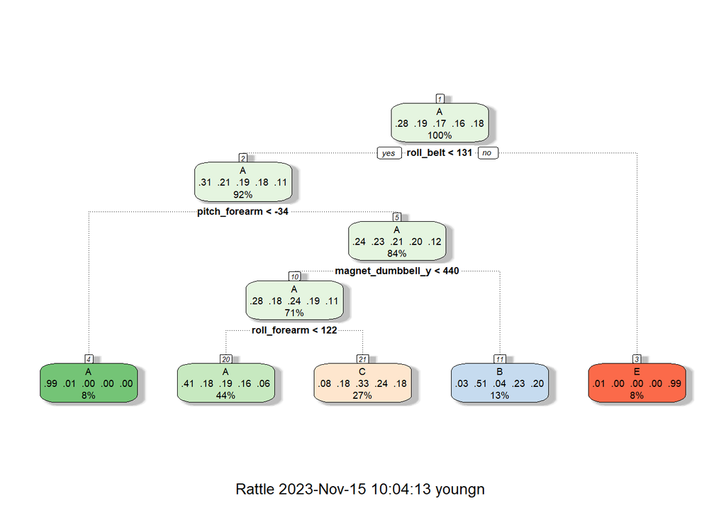

```r
mdl_rpart <- train(classe ~ .,
                   method = "rpart",
                   trControl = trainControl(method = "cv", number = 3),
                   data = train_subset_2)
pred_rpart <- predict(mdl_rpart, train_subset_2)

cM_rpart <- confusionMatrix(as.factor(train_subset_2$classe), pred_rpart)

cM_rpart_valid <- confusionMatrix(as.factor(valid$classe),
                                  predict(mdl_rpart, valid))

fancyRpartPlot(mdl_rpart$finalModel)
```

The resulting classification tree above does a better job of classifying the `classe` outcome as it predicts categories “A”, “B”, “C”, and “E” based on `roll_belt`, `pitch_forearm`, `magnet_dumbell_y` and `roll_forearm`. As category “D” comprises 16% of the data, this model is guaranteed to have imperfect accuracy.

### Random Forest

The final model is a random forest which is available from `randomForest`.

```r
mdl_rf <- randomForest(as.factor(classe) ~ ., data = train_subset_2)

pred_rf <- predict(mdl_rf, train_subset_2)

cM_rf <- confusionMatrix(as.factor(train_subset_2$classe), pred_rf)

cM_rf_valid <- confusionMatrix(as.factor(valid$classe),
                                  predict(mdl_rf, valid))
```

An initial interpretation of this model is difficult so the analysis of it will be left to the next section where we examine the in-sample accuracy and out-sample error rate.

## Results

```r
model_summary <- tibble(
  "Model" = c("rpart with PCA", "rpart", "Random Forest"),
  "In-sample Accuracy" = c(cM_rpart_PC$overall[1],
                            cM_rpart$overall[1],
                            cM_rf$overall[1]),
  "Out-sample Error" = c(1-cM_rpart_PC_valid$overall[1],
                          1-cM_rpart_valid$overall[1],
                          1-cM_rf_valid$overall[1])
)

gt(model_summary, caption = "Model Summary") %>%
  fmt_number(decimals = 4)
```

Model Summary

| Model | In-sample Accuracy | Out-sample Error |
| --- | --- | --- |
| rpart with PCA | 0.3839 | 0.6185 |
| rpart | 0.4948 | 0.5042 |
| Random Forest | 1.0000 | 0.0058 |

## Predictions on Test set

The predictions on the test set are found using the Random Forest model:

```r
predict(mdl_rf, test)
```

```
##  1  2  3  4  5  6  7  8  9 10 11 12 13 14 15 16 17 18 19 20
##  B  A  B  A  A  E  D  B  A  A  B  C  B  A  E  E  A  B  B  B
## Levels: A B C D E
```

## Appendix

### Correlation plot

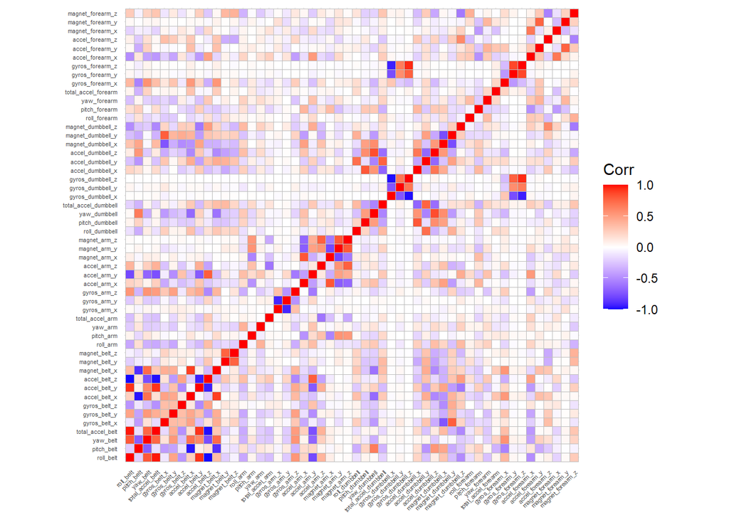

```r
ggcorrplot::ggcorrplot(cor(train_subset_2[,-53]), tl.cex = 4)
```